# Надгледано учење - аутизам код тинејџера

## Додатне библиотеке

У оквиру пројекта коришћене су следеће додатне библиотеке:

```python
import pandas as pd
import numpy as np
from sklearn.model_selection import train_test_split
from sklearn.svm import SVC
from sklearn.metrics import confusion_matrix, classification_report
from sklearn.ensemble import RandomForestClassifier
```

Библиотека *pandas* служи за учитавање података из *.csv* фајла, у жељену структуру података.  
Библиотека *numpy* садржи функције за рад са низовима.  
Библиотека *sklearn* је библиотека за машинско учење.

## Одабир алгоритма за класификацију

Приликом одабира алгоритма за класификацију, разматрано је између *SVM* и *Random forest* алгоритама. Резултати који су добијени су следећи.

```python
def classificationSvm(data):
    # Ucitavanje podataka
    df = pd.read_csv(data+'.csv')

    # Izvlacenje klasnog atributa
    labels = np.array(df['Class/ASD'])
    df = df.drop('Class/ASD', axis=1)
    df = np.array(df)

    # podela na trening itest skup
    train, test, train_labels, test_labels = train_test_split(df,
                                                              labels,
                                                              stratify=labels,
                                                              test_size=0.33,
                                                              random_state=0)

    # Random forest klasifikator, inicijalizacija
    model = SVC(kernel='linear')

    # Treniranje modela
    model.fit(train, train_labels)


    # Trening predikci

    # Test predikcija
    rf_predictions = model.predict(test)
    print(confusion_matrix(test_labels,rf_predictions))
    print(classification_report(test_labels,rf_predictions))


def classificationRF(data):
    df = pd.read_csv(data + '.csv')

    # Izvlacenje klasnog atributa
    labels = np.array(df['Class/ASD'])
    df = df.drop('Class/ASD', axis=1)
    df = np.array(df)

    # podela na trening itest skup
    train, test, train_labels, test_labels = train_test_split(df,
                                                              labels,
                                                              stratify=labels,
                                                              test_size=0.33,
                                                              random_state=0)

    # Random forest klasifikator, inicijalizacija
    model = RandomForestClassifier(n_estimators=100,
                                   random_state=0,
                                   max_features='sqrt',
                                   n_jobs=-1, verbose=1)

    # Treniranje modela
    model.fit(train, train_labels)


    # Test predikcija
    rf_predictions = model.predict(test)
    print(confusion_matrix(test_labels,rf_predictions))
    print(classification_report(test_labels,rf_predictions))



classificationSvm('PPodaci')
classificationRF('PPodaci')
```

```
[[14  0]
 [ 0 21]]
              precision    recall  f1-score   support

           0       1.00      1.00      1.00        14
           1       1.00      1.00      1.00        21

    accuracy                           1.00        35
   macro avg       1.00      1.00      1.00        35
weighted avg       1.00      1.00      1.00        35
```

[output not shown]

```
[[14  0]
 [ 0 21]]
              precision    recall  f1-score   support

           0       1.00      1.00      1.00        14
           1       1.00      1.00      1.00        21

    accuracy                           1.00        35
   macro avg       1.00      1.00      1.00        35
weighted avg       1.00      1.00      1.00        35
```

На основу приказаних резултата, дошло се до закључка да ће одабир било ког алгоритма донети исте резултате. На крају је одлучено да се као алгоритам класификације узме *Random forest* алгоритам.

## Учитавање података и пречишћени подаци

```python
df = pd.read_csv('Podaci.csv')
df
```

|  | A1_Score | A2_Score | A3_Score | A4_Score | A5_Score | A6_Score | A7_Score | A8_Score | A9_Score | A10_Score | age | gender | jundice | austim | used_app_before | result | age_desc | relation | Class/ASD |
| --- | --- | --- | --- | --- | --- | --- | --- | --- | --- | --- | --- | --- | --- | --- | --- | --- | --- | --- | --- |
| 0 | 0 | 0 | 0 | 1 | 1 | 1 | 1 | 1 | 1 | 0 | 15 | 1 | 1 | 1 | 0 | 6 | 0 | 0 | 0 |
| 1 | 0 | 0 | 0 | 0 | 0 | 0 | 0 | 0 | 1 | 1 | 15 | 1 | 0 | 0 | 0 | 2 | 0 | 1 | 0 |
| 2 | 0 | 0 | 0 | 0 | 0 | 0 | 0 | 0 | 1 | 1 | 12 | 0 | 0 | 0 | 0 | 2 | 0 | 5 | 0 |
| 3 | 0 | 1 | 1 | 1 | 1 | 1 | 0 | 1 | 1 | 0 | 14 | 0 | 0 | 0 | 0 | 7 | 0 | 2 | 1 |
| 4 | 1 | 1 | 1 | 1 | 1 | 1 | 1 | 0 | 0 | 0 | 16 | 0 | 0 | 0 | 0 | 7 | 0 | 5 | 1 |
| ... | ... | ... | ... | ... | ... | ... | ... | ... | ... | ... | ... | ... | ... | ... | ... | ... | ... | ... | ... |
| 99 | 0 | 1 | 1 | 1 | 0 | 1 | 1 | 0 | 1 | 0 | 16 | 0 | 0 | 0 | 1 | 6 | 1 | 0 | 0 |
| 100 | 1 | 0 | 1 | 0 | 0 | 0 | 0 | 1 | 0 | 1 | 16 | 1 | 0 | 0 | 0 | 4 | 1 | 0 | 0 |
| 101 | 1 | 0 | 0 | 1 | 1 | 1 | 1 | 1 | 1 | 1 | 12 | 0 | 0 | 0 | 0 | 8 | 0 | 2 | 1 |
| 102 | 1 | 1 | 0 | 1 | 1 | 0 | 0 | 0 | 1 | 1 | 13 | 0 | 0 | 0 | 0 | 6 | 0 | 2 | 0 |
| 103 | 1 | 0 | 1 | 0 | 0 | 1 | 1 | 1 | 1 | 0 | 12 | 1 | 0 | 0 | 0 | 6 | 0 | 0 | 0 |

104 rows × 19 columns

У табели изнад приказан је непрочишћени скуп података. Ради постизања што бољих перформанси подигнуто је стабло одлуке, да би се одредио утицај одређених атрибута на класификацију.

```python
from subprocess import call
from sklearn.tree import export_graphviz
from IPython.display import  Image

def tree(data):
    # Ucitavanje podataka
    dg = pd.read_csv(data + '.csv')

    # Izvlacenje klasnog atributa
    labels = np.array(dg['Class/ASD'])
    dg = dg.drop('Class/ASD', axis=1)
    df = np.array(dg)

    # podela na trening itest skup
    train, test, train_labels, test_labels = train_test_split(df,
                                                              labels,
                                                              stratify=labels,
                                                              test_size=0.33,
                                                              random_state=0)

    col = dg.columns.values

    # Random forest klasifikator, inicijalizacija
    model = RandomForestClassifier(n_estimators=100,
                                   random_state=0,
                                   max_features='sqrt',
                                   n_jobs=-1, verbose=1)

    # Treniranje modela
    model.fit(train, train_labels)
    estimator = model.estimators_[5]

    # Eksport kao dot fajl
    export_graphviz(estimator, out_file=data + '.dot',
                    feature_names=col,
                    class_names='Class/ASD',
                    rounded=True, proportion=False,
                    precision=2, filled=True)

    call(['dot', '-Tpng', data + '.dot', '-o', data + '.png', '-Gdpi=600'])

    Image(filename=data+'.png')


def mainTree(data1):
    tree(data1)

mainTree('Podaci')
```

```
[Parallel(n_jobs=-1)]: Using backend ThreadingBackend with 12 concurrent workers.
[Parallel(n_jobs=-1)]: Done  26 tasks      | elapsed:    0.0s
[Parallel(n_jobs=-1)]: Done 100 out of 100 | elapsed:    0.0s finished
```

[figure not shown]

Након генерисања стабла одлуке, одлучено је да се поједини атрибути избаце, из разлога што не утичу на процес класификације података. У наставку биће приказан скуп прочишћених података.

```python
df = pd.read_csv('PPodaci.csv')
df
```

|  | A2_Score | A3_Score | A5_Score | A9_Score | A10_Score | result | Class/ASD |
| --- | --- | --- | --- | --- | --- | --- | --- |
| 0 | 0 | 0 | 1 | 1 | 0 | 6 | 0 |
| 1 | 0 | 0 | 0 | 1 | 1 | 2 | 0 |
| 2 | 0 | 0 | 0 | 1 | 1 | 2 | 0 |
| 3 | 1 | 1 | 1 | 1 | 0 | 7 | 1 |
| 4 | 1 | 1 | 1 | 0 | 0 | 7 | 1 |
| ... | ... | ... | ... | ... | ... | ... | ... |
| 99 | 1 | 1 | 0 | 1 | 0 | 6 | 0 |
| 100 | 0 | 1 | 0 | 0 | 1 | 4 | 0 |
| 101 | 0 | 0 | 1 | 1 | 1 | 8 | 1 |
| 102 | 1 | 0 | 1 | 1 | 1 | 6 | 0 |
| 103 | 0 | 1 | 0 | 1 | 0 | 6 | 0 |

104 rows × 7 columns

Стабло одлуке над овим скупом података приказано је на следећој слици:

[figure not shown]

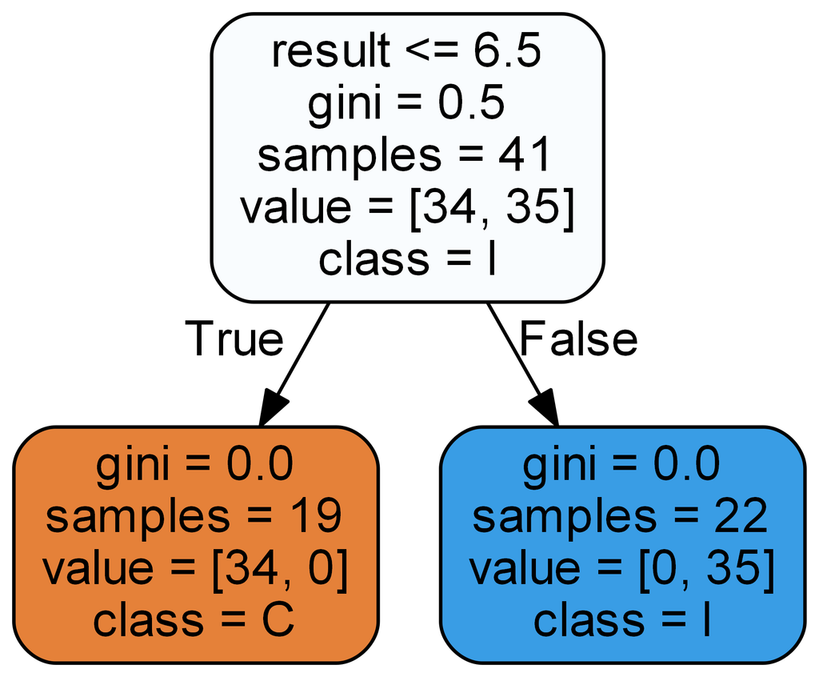

На слици се види, да је једини атрибут који утиче на класификацију атрибут *result*, што доводи до закључка да се приликом пречишћавања података може узимати само један најбољи атрибут.

```python
df = pd.read_csv('PPodaci.csv')
df
```

|  | result | Class/ASD |
| --- | --- | --- |
| 0 | 6 | 0 |
| 1 | 2 | 0 |
| 2 | 2 | 0 |
| 3 | 7 | 1 |
| 4 | 7 | 1 |
| ... | ... | ... |
| 99 | 6 | 0 |
| 100 | 4 | 0 |
| 101 | 8 | 1 |
| 102 | 6 | 0 |
| 103 | 6 | 0 |

104 rows × 2 columns

```python
from sklearn.feature_selection import SelectKBest
from sklearn.feature_selection import f_classif
from sklearn.ensemble import RandomForestClassifier
from sklearn.feature_selection import RFE as RFEE
import pandas as pd
import numpy as np


def SelKBest(data, n):
    df = pd.read_csv(data+'.csv')

    # Izvlacenje klasnog atributa
    labels = df['Class/ASD']
    df = df.drop('Class/ASD', axis=1)
    cols = df.columns

    # feature extraction
    test = SelectKBest(score_func=f_classif, k=n)
    fit = test.fit(df, labels)
    # summarize scores
    np.set_printoptions(precision=3)
    # summarize selected features
    br = fit.get_support(indices=True)
    col = []
    for i in range(len(cols)):
        if i not in br:
            col.append(cols[i])
    print(br)
    df_new = df.drop(columns=col, axis=1)
    df_new = df_new.join(labels)

    df_new.to_csv('PPodaci.csv')


def RFE(data, n):
    df = pd.read_csv(data + '.csv')

    # Izvlacenje klasnog atributa
    labels = df['Class/ASD']
    df = df.drop('Class/ASD', axis=1)
    cols = df.columns
    # feature extraction
    model = RandomForestClassifier(n_estimators=100)
    rfe = RFEE(model, n)
    fit = rfe.fit(df, labels)

    br = fit.get_support(indices=True)
    print(br)


RFE('Podaci', 1)
SelKBest('Podaci', 1)
```

```
[15]
[15]
```

Добијени резултати применом оба алгоритма су идентични, што доводи до закључка да је потребно избацити све остале елементе.

## Класификација података и резултати класификације

У наставку ће бити приказана имплементација и резултати класификације над непрочишћеним и прочишћеним подацима. Функције за визуелизацију су имплементиране у оквиру посебног фајла.

[output not shown]

```
Prosecan broj cvorova 14
Prosecna maksimalna dubina 3
```

[output not shown]

```
Recall Baseline: 1.0 Test: 1.0 Train: 1.0
Precision Baseline: 0.6 Test: 1.0 Train: 1.0
Roc Baseline: 0.5 Test: 1.0 Train: 1.0
```

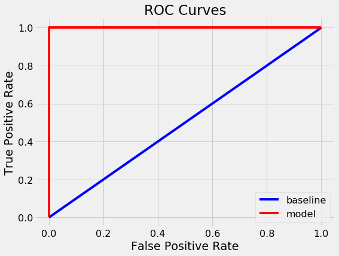

```
Confusion matrix, without normalization
[[14  0]
 [ 0 21]]
```

[output not shown]

```
Prosecan broj cvorova 6
Prosecna maksimalna dubina 2
```

[output not shown]

```
Recall Baseline: 1.0 Test: 1.0 Train: 1.0
Precision Baseline: 0.6 Test: 1.0 Train: 1.0
Roc Baseline: 0.5 Test: 1.0 Train: 1.0
```

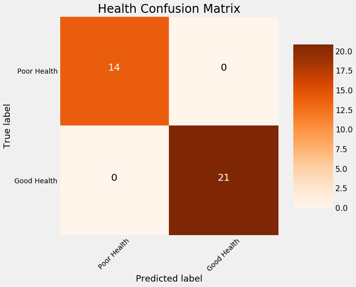

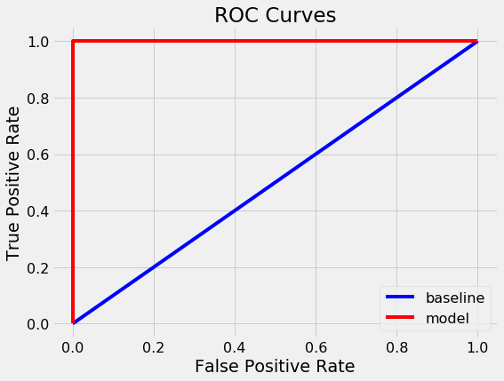

```
Confusion matrix, without normalization
[[14  0]
 [ 0 21]]
```

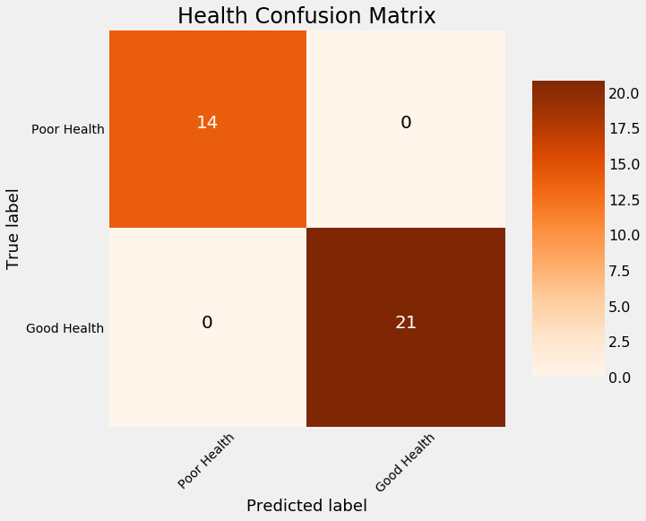

```python
import pandas as pd
import numpy as np
from sklearn.model_selection import train_test_split
from sklearn.ensemble import RandomForestClassifier
import matplotlib.pyplot as plt
from sklearn.metrics import confusion_matrix
import vizualizacija as vs


def classification(data):
    # Ucitavanje podataka
    df = pd.read_csv(data+'.csv')

    # Izvlacenje klasnog atributa
    labels = np.array(df['Class/ASD'])
    df = df.drop('Class/ASD', axis=1)
    df = np.array(df)

    # podela na trening itest skup
    train, test, train_labels, test_labels = train_test_split(df,
                                                              labels,
                                                              stratify=labels,
                                                              test_size=0.33,
                                                              random_state=0)

    # Random forest klasifikator, inicijalizacija
    model = RandomForestClassifier(n_estimators=100,
                                   random_state=0,
                                   max_features='sqrt',
                                   n_jobs=-1, verbose=1)

    # Treniranje modela
    model.fit(train, train_labels)

    n_cvorova = []
    max_dubina = []

    # Statistika
    for ind_tree in model.estimators_:
        n_cvorova.append(ind_tree.tree_.node_count)
        max_dubina.append(ind_tree.tree_.max_depth)

    print(f'Prosecan broj cvorova {int(np.mean(n_cvorova))}')
    print(f'Prosecna maksimalna dubina {int(np.mean(max_dubina))}')

    # Trening predikcija
    train_rf_predictions = model.predict(train)
    train_rf_probs = model.predict_proba(train)[:, 1]

    # Test predikcija
    rf_predictions = model.predict(test)
    rf_probs = model.predict_proba(test)[:, 1]

    # Grafikon
    plt.style.use('fivethirtyeight')
    plt.rcParams['font.size'] = 18



    vs.evaluate_model(rf_predictions, rf_probs, train_rf_predictions, train_rf_probs, test_labels, train_labels)

    cm = confusion_matrix(test_labels, rf_predictions)
    vs.plot_confusion_matrix(cm, classes=['Poor Health', 'Good Health'],
                          title='Health Confusion Matrix')

    plt.savefig(data+'Matrix.png')


def mainClassification(data1, data2):
    classification(data1)
    classification(data2)

mainClassification('Podaci','PPodaci')
```